# Results: Plots and Tables

2024-08-05

This report contains different plots and tables that may be relevant for analysing the results. Observe:

- The hypercube $Y_N$ is placed in, is approx. $[0, 10000m]^p$, since for each subproblem $Y_N^s \subset [0, 10000]^p$. That is, more subproblems create a larger hypercube for the master problem and the volume (number of integer points) grows exponentially in $p$.
- Given $|Y_N|$, we can find the hypercube as
  $$[l_1, u_1] \times \cdots
  \times [l_p, u_p],$$
  where $l_i = \min_{y \in Y_N}(y_i)$ and $u_i = \max_{y \in Y_N}(y_i)$.
- The number of integer points in the hypercube is
  $$\prod_{i = 1}^p (u_i - l_i + 1)$$

## Statistics for `alg1`

Given a problem consisting of $m$ subproblems with $Y_N^s$ given for each subproblem $s$, we use a filtering algorithm to find $Y_N$ (`alg1`).

The following instance/problem groups are generated given:

- $p=2,\ldots, 5$. [4 options]
- $m=2,\ldots 5$ where $m$ is the number of subproblems. [4 options]
- All subproblems have the same method config or half have method `u` and `l`. [4 options]
- Five instances for each config. [5 options]

### Status

- 590/1600 problems have been solved, i.e. 1010 remaining.
- 590/590 problems have 5 instances solved for each configuration.
- 221/590 have not been classified.
- 0/590 have not been fully classified (only classified extreme).

### Problems solved for the analysis

|  | path | p | card | supported | extreme | unsupported | min1 | min2 | max1 | max2 | width1 | width2 | filter_time | spCard1 | spCard2 | spSupported1 | spSupported2 | spExtreme1 | spExtreme2 | spUnsupported1 | spUnsupported2 | spCard3 | spSupported3 | spExtreme3 | spUnsupported3 | spCard4 | spSupported4 | spExtreme4 | spUnsupported4 | … |
| --- | --- | --- | --- | --- | --- | --- | --- | --- | --- | --- | --- | --- | --- | --- | --- | --- | --- | --- | --- | --- | --- | --- | --- | --- | --- | --- | --- | --- | --- | --- |
| 1 | alg1-prob-2-100\|100-mm-2_1.json | 2 | 700 | 14 | 14 | 686 | 2 | 23 | 17885 | 17564 | 17883 | 17541 | 0.0541 | 100 | 100 | 7 | 8 | 7 | 8 | 93 | 92 |  |  |  |  |  |  |  |  | … |
| 2 | alg1-prob-2-100\|100-mm-2_2.json | 2 | 746 | 17 | 17 | 729 | 2 | 8 | 18312 | 17957 | 18310 | 17949 | 0.0455 | 100 | 100 | 8 | 10 | 8 | 10 | 92 | 90 |  |  |  |  |  |  |  |  | … |
| 3 | alg1-prob-2-100\|100-mm-2_3.json | 2 | 678 | 19 | 19 | 659 | 3 | 6 | 18371 | 17364 | 18368 | 17358 | 0.047 | 100 | 100 | 8 | 12 | 8 | 12 | 92 | 88 |  |  |  |  |  |  |  |  | … |
| 4 | alg1-prob-2-100\|100-mm-2_4.json | 2 | 678 | 19 | 19 | 659 | 3 | 6 | 18371 | 17364 | 18368 | 17358 | 0.0559 | 100 | 100 | 8 | 12 | 8 | 12 | 92 | 88 |  |  |  |  |  |  |  |  | … |
| 5 | alg1-prob-2-100\|100-mm-2_5.json | 2 | 733 | 20 | 20 | 713 | 6 | 3 | 17661 | 18580 | 17655 | 18577 | 0.0474 | 100 | 100 | 11 | 10 | 11 | 10 | 89 | 90 |  |  |  |  |  |  |  |  | … |
| 6 | alg1-prob-2-100\|100-uu-2_1.json | 2 | 366 | 3 | 3 | 363 | 41 | 196 | 19999 | 20000 | 19958 | 19804 | 0.0456 | 100 | 100 | 2 | 2 | 2 | 2 | 98 | 98 |  |  |  |  |  |  |  |  | … |
| 7 | alg1-prob-2-100\|100-uu-2_2.json | 2 | 364 | 3 | 3 | 361 | 32 | 172 | 19999 | 20000 | 19967 | 19828 | 0.0454 | 100 | 100 | 2 | 2 | 2 | 2 | 98 | 98 |  |  |  |  |  |  |  |  | … |
| 8 | alg1-prob-2-100\|100-uu-2_3.json | 2 | 344 | 3 | 3 | 341 | 194 | 356 | 19994 | 19999 | 19800 | 19643 | 0.0457 | 100 | 100 | 2 | 2 | 2 | 2 | 98 | 98 |  |  |  |  |  |  |  |  | … |
| 9 | alg1-prob-2-100\|100-uu-2_4.json | 2 | 299 | 3 | 3 | 296 | 144 | 162 | 19999 | 19999 | 19855 | 19837 | 0.0482 | 100 | 100 | 2 | 2 | 2 | 2 | 98 | 98 |  |  |  |  |  |  |  |  | … |
| 10 | alg1-prob-2-100\|100-uu-2_5.json | 2 | 385 | 3 | 3 | 382 | 105 | 79 | 20000 | 20000 | 19895 | 19921 | 0.048 | 100 | 100 | 2 | 2 | 2 | 2 | 98 | 98 |  |  |  |  |  |  |  |  | … |

[output cut: 580 more lines]

Note that the width of objective $i = 1, \ldots p$, $w_i = [l_i, u_i]$ should be approx. $10000m$. Check:

```
## # A tibble: 4 × 6
##       m mean_width1 mean_width2 mean_width3 mean_width4 mean_width5
##   <dbl>       <dbl>       <dbl>       <dbl>       <dbl>       <dbl>
## 1     2      19208.      19201.      19371.      19115.      18829.
## 2     3      28665.      28760.      28915.      28653.      28079.
## 3     4      38098.      38229.      38367.      37928.      37041.
## 4     5      47125.      47586.      47515.      46924.      44537.
```

### Size of $Y_N$

What is $|Y_N|$ given the different methods of generating the set of nondominated points for the subproblems?

```
## # A tibble: 2 × 3
##   method mean_card     n
##   <chr>      <dbl> <int>
## 1 m        411493.   295
## 2 u        104870.   295
```

Does $p$ have an effect?

```
## # A tibble: 8 × 4
## # Groups:   method [2]
##   method     p mean_card     n
##   <chr>  <dbl>     <dbl> <int>
## 1 m          2     5528.    75
## 2 u          2     1059.    75
## 3 m          3   105312.    75
## 4 u          3    10077     75
## 5 m          4   476291.    75
## 6 u          4    79341.    75
## 7 m          5  1105081.    70
## 8 u          5   345012.    70
```

Does $m$ have an effect?

```
## # A tibble: 8 × 4
## # Groups:   method [2]
##   method     m mean_card     n
##   <chr>  <dbl>     <dbl> <int>
## 1 m          2     5688.    80
## 2 u          2     4201.    80
## 3 m          3    90077.    80
## 4 u          3    37283.    80
## 5 m          4   874692.    80
## 6 u          4   190675.    80
## 7 m          5   795527.    55
## 8 u          5   224798.    55
```

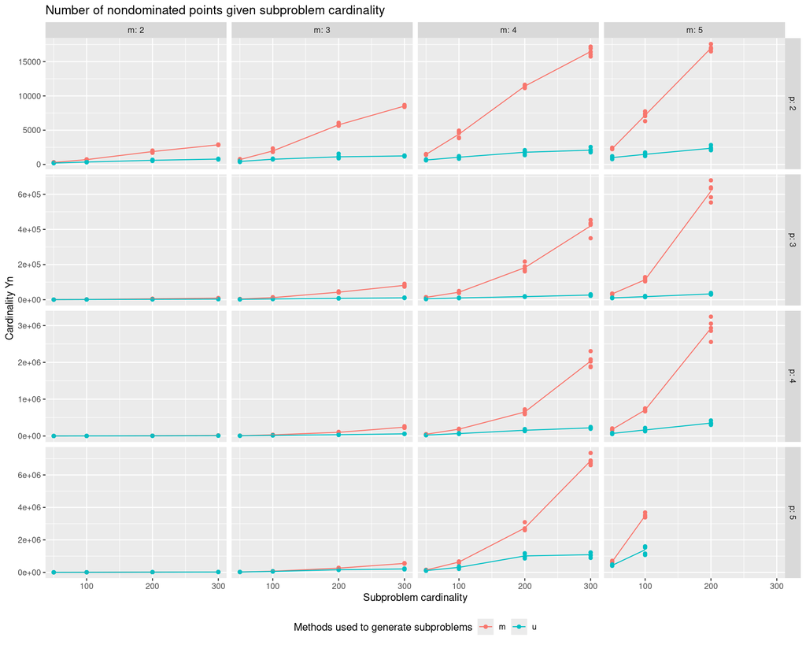

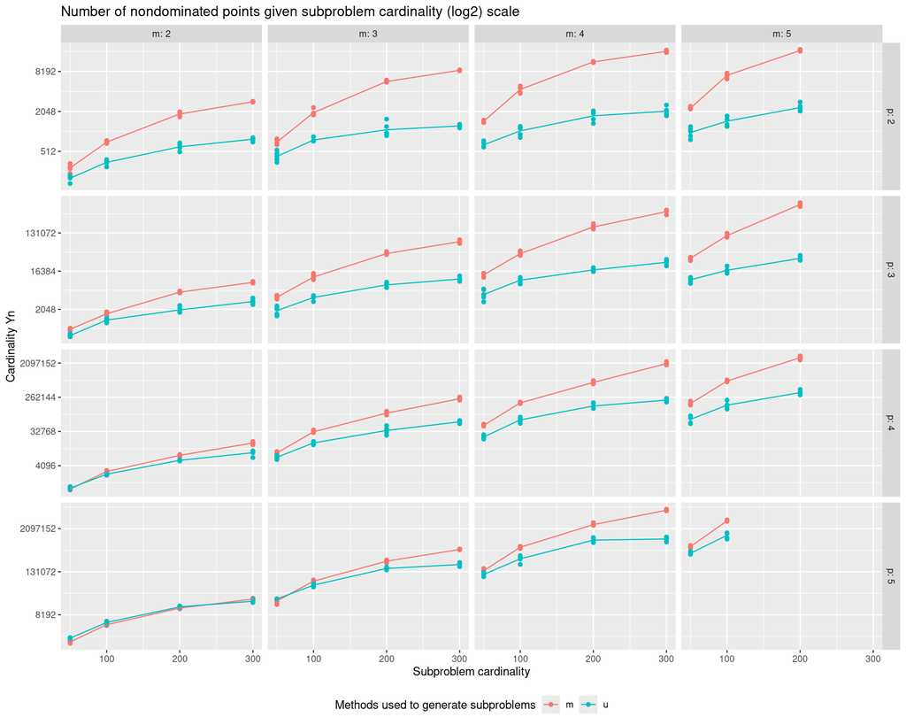

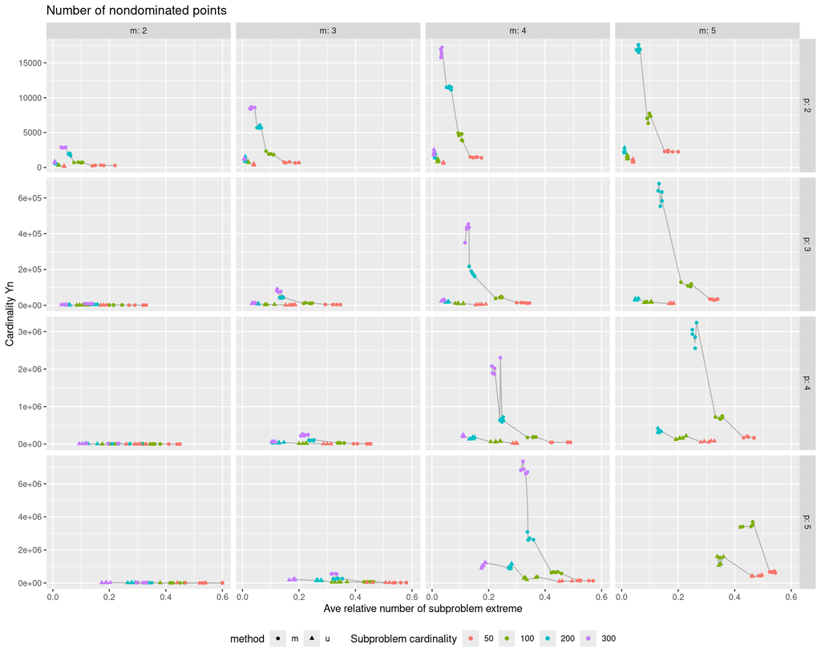

### Relative size of $Y_N$

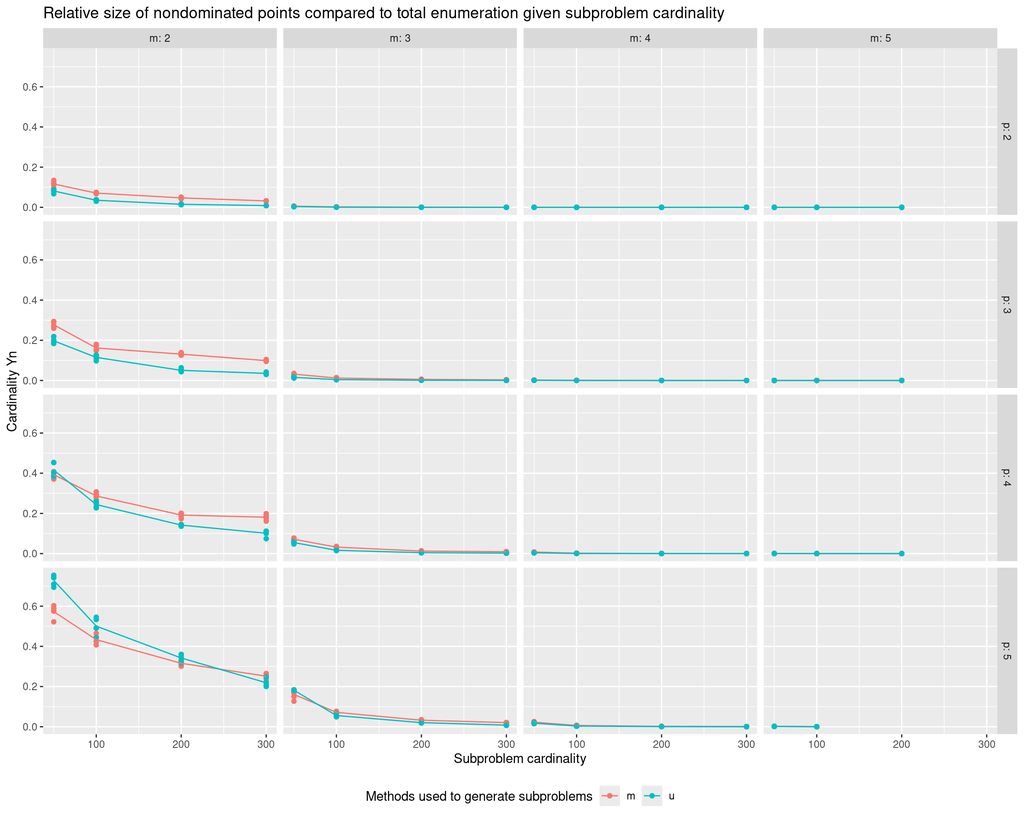

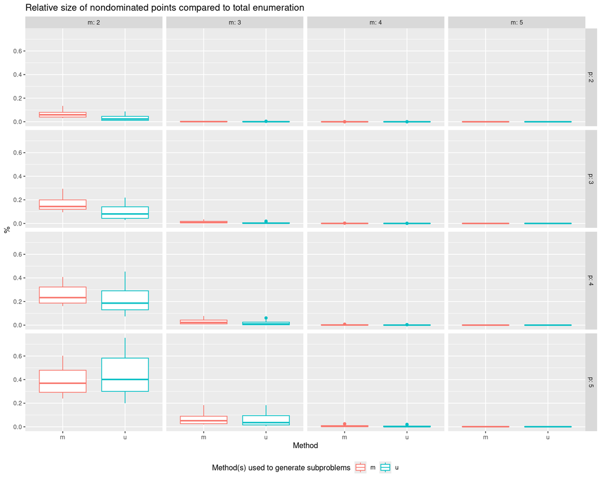

### Nondominated points classification

We classify the nondominated points into, extreme, supported non-extreme and unsupported.

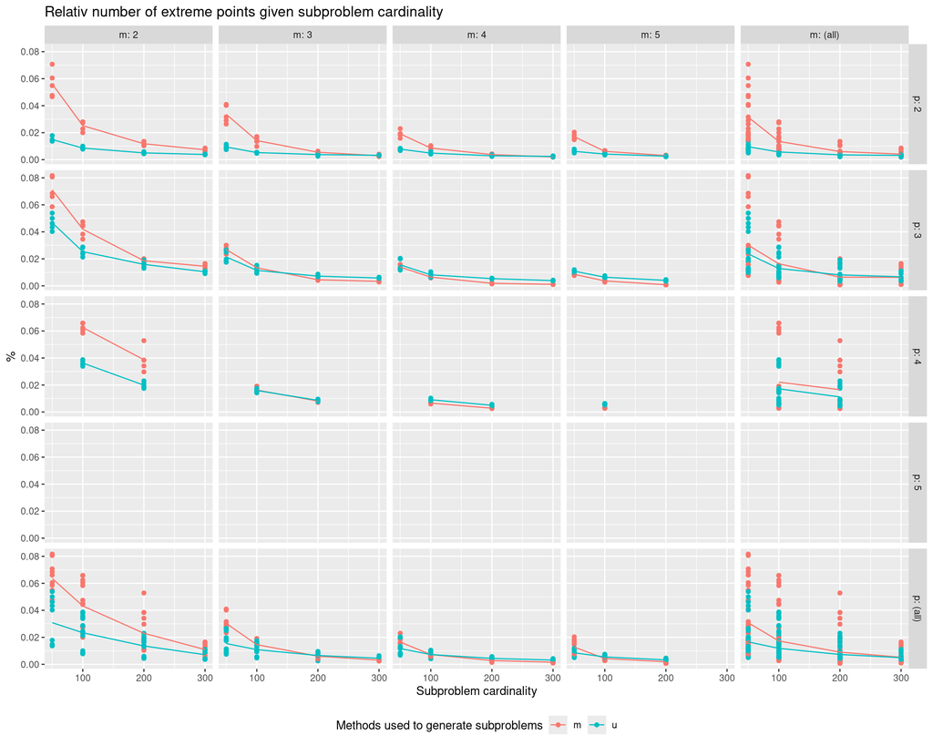

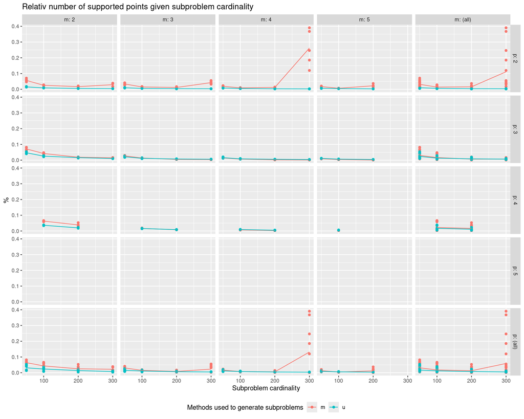

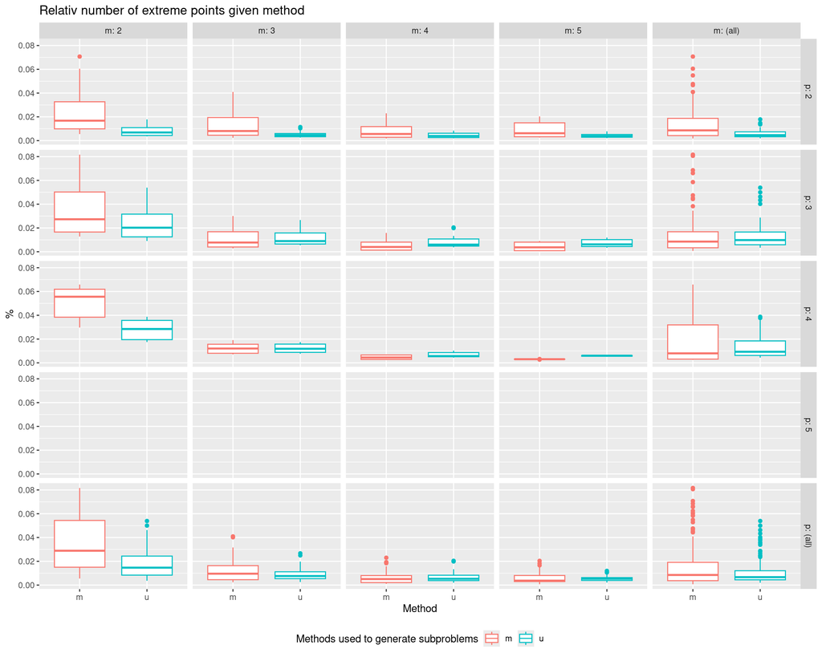

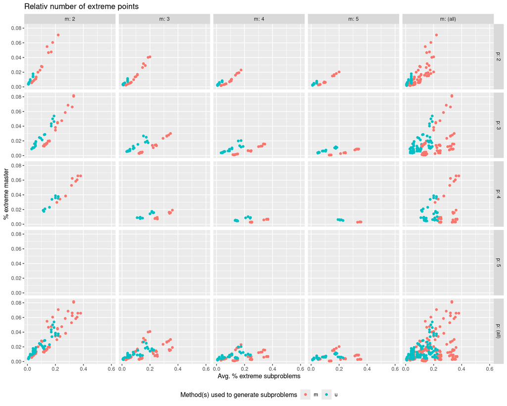

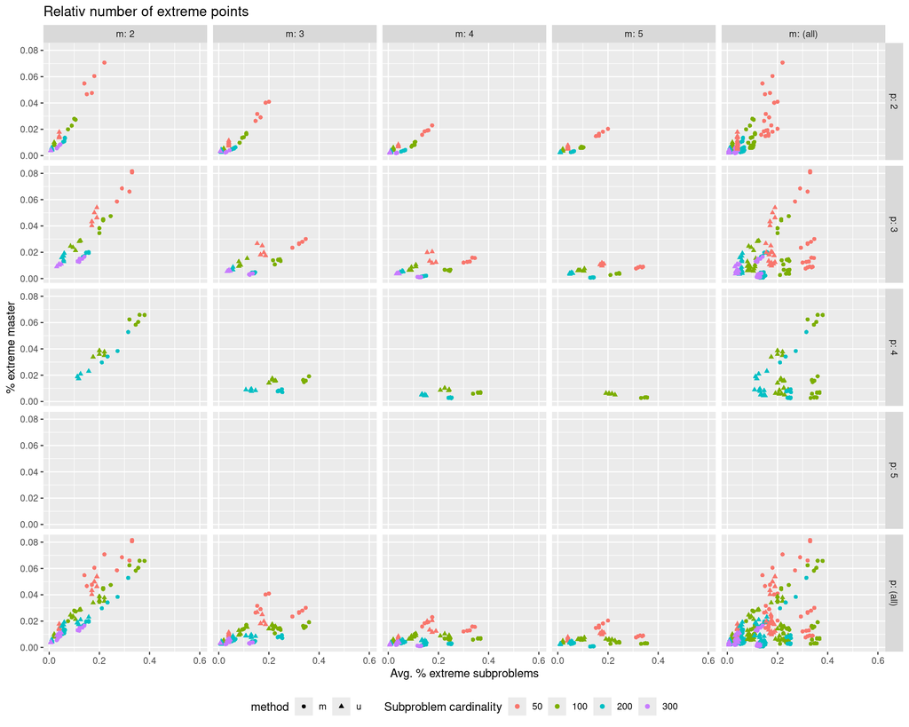

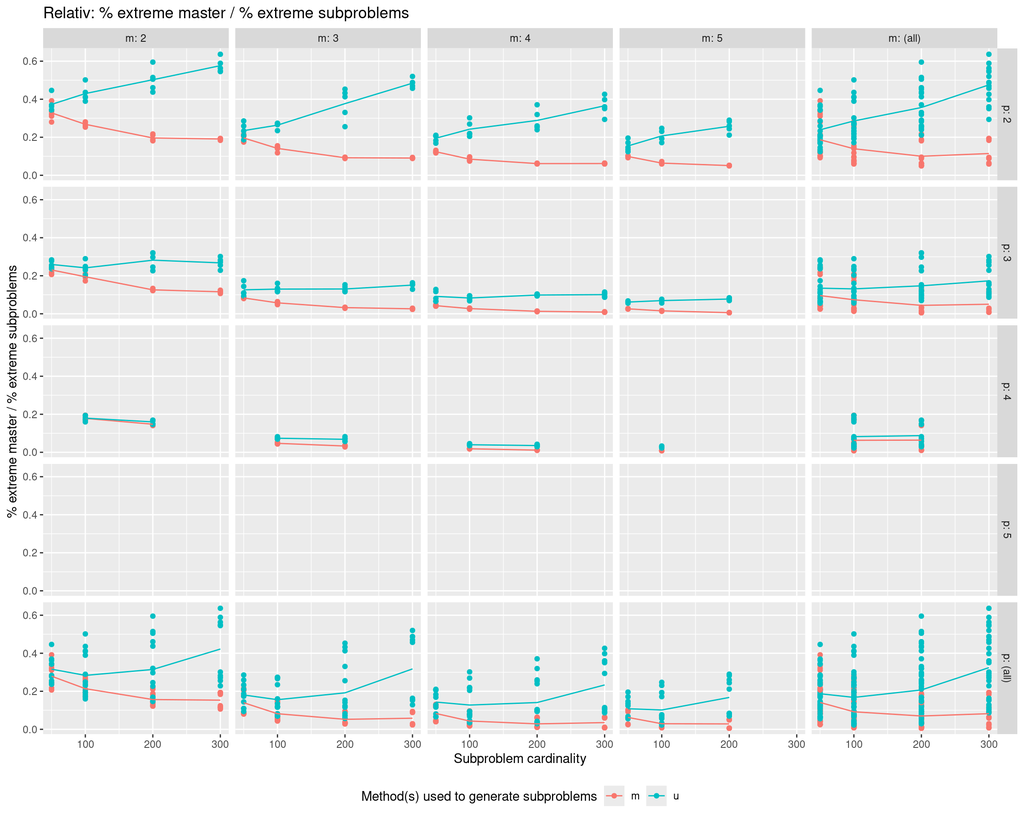